# Different ways of using color palettes in tmap

Shefali C.

2023-05-01

```r
library(tmap)
library(dplyr)
library(ggplot2)
library(sf)
data("World", "NLD_muni", "NLD_prov", metro, rivers, land)
```

CRS value in the built-in *`metro`* dataframe is of *proj4string* type. This format has long been deprecated. In the following code, the CRS is being converted to *WKT* format, which is the most accepted format.  
This is not a mandatory step but I’ve done this to avoid warning message thrown during map creation.

```r
#Convert old CRS 'proj4string' to new EPSG in metro dataset

#check for current crs
str(attr(metro$geometry, "crs"))
```

```
## List of 2
##  $ epsg       : int 4326
##  $ proj4string: chr "+proj=longlat +datum=WGS84 +no_defs"
##  - attr(*, "class")= chr "crs"
```

```r
#convert to EPSG 'wkt' format
sf::st_crs(metro) <- 4326
```

```
## old-style crs object detected; please recreate object with a recent sf::st_crs()
```

*grDevices* is an inbuilt package in R. Custome palettes can be created using *`hcl.colors()`* function. Code chunk below displays all color palettes names that can be used in this `hcl.colors()` function.

`hcl.colors()` can be used to create palette using palettes from different packages like *viridis, RColorBrewer* etc.

```r
#names of all palettes
hcl.pals()
```

```
##   [1] "Pastel 1"      "Dark 2"        "Dark 3"        "Set 2"
##   [5] "Set 3"         "Warm"          "Cold"          "Harmonic"
##   [9] "Dynamic"       "Grays"         "Light Grays"   "Blues 2"
##  [13] "Blues 3"       "Purples 2"     "Purples 3"     "Reds 2"
##  [17] "Reds 3"        "Greens 2"      "Greens 3"      "Oslo"
##  [21] "Purple-Blue"   "Red-Purple"    "Red-Blue"      "Purple-Orange"
##  [25] "Purple-Yellow" "Blue-Yellow"   "Green-Yellow"  "Red-Yellow"
##  [29] "Heat"          "Heat 2"        "Terrain"       "Terrain 2"
##  [33] "Viridis"       "Plasma"        "Inferno"       "Rocket"
##  [37] "Mako"          "Dark Mint"     "Mint"          "BluGrn"
##  [41] "Teal"          "TealGrn"       "Emrld"         "BluYl"
##  [45] "ag_GrnYl"      "Peach"         "PinkYl"        "Burg"
##  [49] "BurgYl"        "RedOr"         "OrYel"         "Purp"
##  [53] "PurpOr"        "Sunset"        "Magenta"       "SunsetDark"
##  [57] "ag_Sunset"     "BrwnYl"        "YlOrRd"        "YlOrBr"
##  [61] "OrRd"          "Oranges"       "YlGn"          "YlGnBu"
##  [65] "Reds"          "RdPu"          "PuRd"          "Purples"
##  [69] "PuBuGn"        "PuBu"          "Greens"        "BuGn"
##  [73] "GnBu"          "BuPu"          "Blues"         "Lajolla"
##  [77] "Turku"         "Hawaii"        "Batlow"        "Blue-Red"
##  [81] "Blue-Red 2"    "Blue-Red 3"    "Red-Green"     "Purple-Green"
##  [85] "Purple-Brown"  "Green-Brown"   "Blue-Yellow 2" "Blue-Yellow 3"
##  [89] "Green-Orange"  "Cyan-Magenta"  "Tropic"        "Broc"
##  [93] "Cork"          "Vik"           "Berlin"        "Lisbon"
##  [97] "Tofino"        "ArmyRose"      "Earth"         "Fall"
## [101] "Geyser"        "TealRose"      "Temps"         "PuOr"
## [105] "RdBu"          "RdGy"          "PiYG"          "PRGn"
## [109] "BrBG"          "RdYlBu"        "RdYlGn"        "Spectral"
## [113] "Zissou 1"      "Cividis"       "Roma"
```

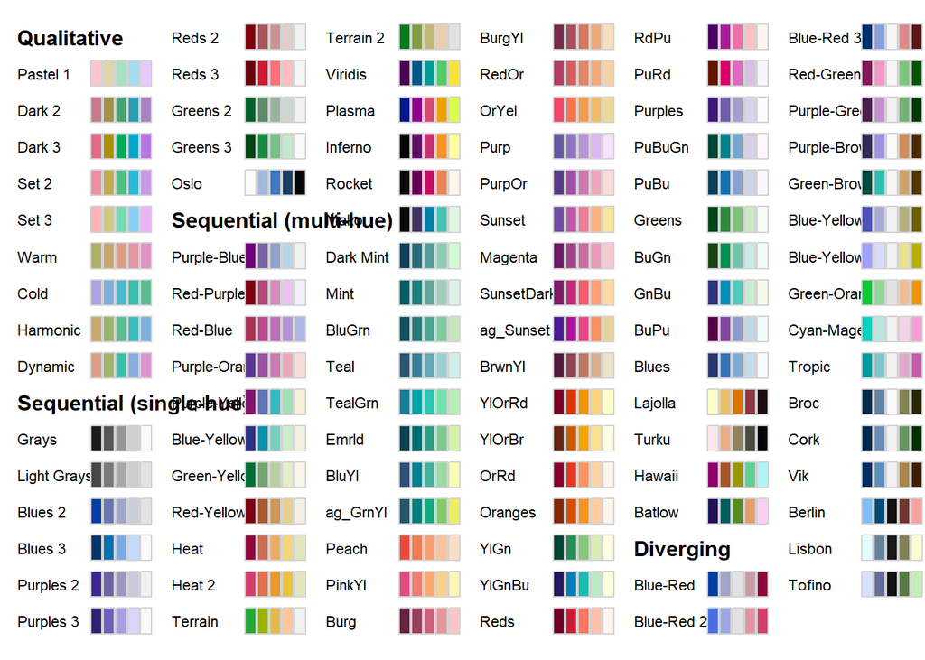

```r
#displaying available palettes for hcl.colors() function
colorspace::hcl_palettes(plot = T)
```

### 3 methods of assigning palettes to any map

#### Method 1: Assign vector of color names

If number of colors provided is low, tmap automatically creates range in the colors depending on values of the variable (here, life expectancy).

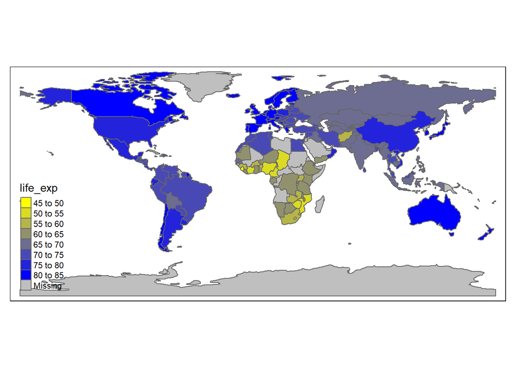

```r
#method 1- use a vector of color names
tm_shape(World)+
  tm_polygons(col = "life_exp", palette = c("yellow", "blue"))
```

#### Method 2: Using a built-in palette name

Adding negative sign infront of palette names reverses the order of colors.

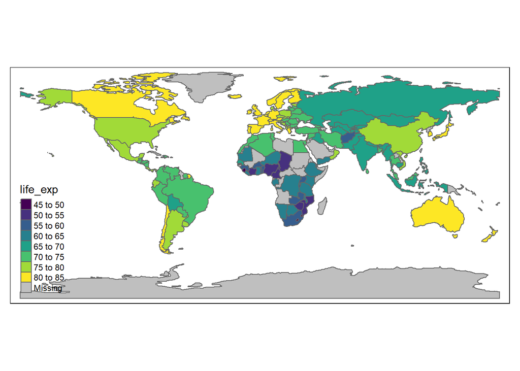

```r
#method 2- built-in palette name
tm_shape(World)+
  tm_polygons(col = "life_exp", palette = "viridis")
```

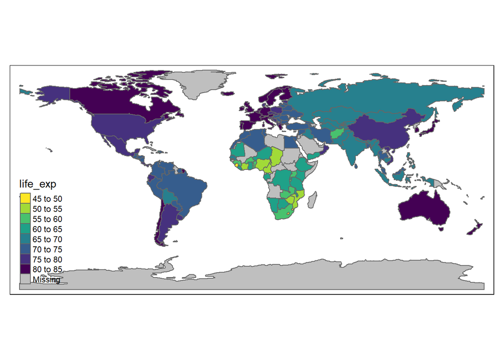

```r
#reversing the order of colors
tm_shape(World)+
  tm_polygons(col = "life_exp", palette = "-viridis")
```

#### Method 3: Calling palette function to select n number of colors in a palette

1. `hcl.colors()` function selects 5 colors from **inferno** palette.
2. `rev()` function has been used to reverse the order of colors.

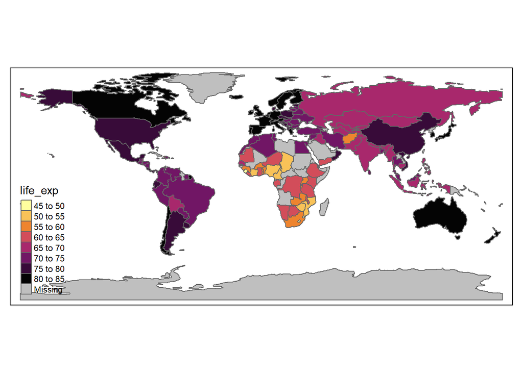

```r
#method 3- output of a palette function
tm_shape(World)+
  tm_polygons(col = "life_exp", palette = rev(hcl.colors(n = 5, palette = "inferno")))
```

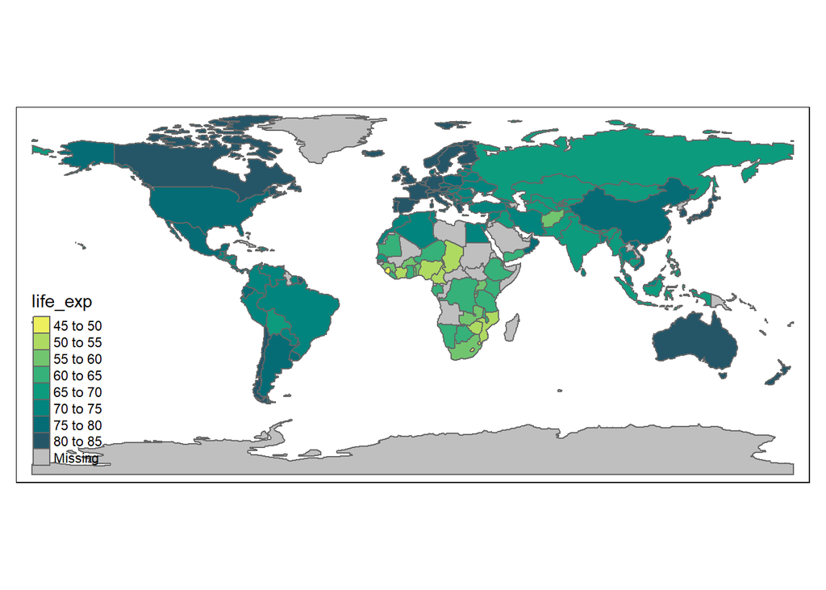

```r
tm_shape(World)+
  tm_polygons(col = "life_exp", palette = rev(hcl.colors(7, "ag_GrnYl")))
```

### When should diverging palettes be used?

Diverging palettes can be used when values in a variable differ in both directions. Let’s say, a variable x contains negative and positive numbers both. In this case, a diverging palette can be used to color the map. By default, midpoint of the x variable is taken as 0. So One kind of sequence coloring is used from -ve values to 0 and other kind of sequence color is used from 0 to positive values.

e.g. Yellow is used from Dark to light shade as values from negative towards 0. And Red is used from light to darker shade on moving from 0 to higher positive end.

We can set our own midpoint values too.

Try being authentic. For e.g. if variable being used to color map is life expectancy. Find the median life expectancy of the dataset. Then use it.

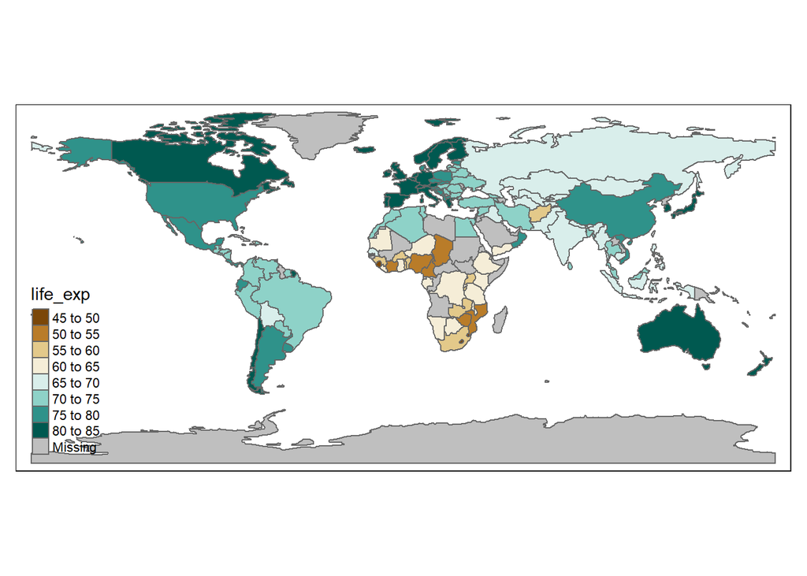

```r
#diverging palette
tm_shape(World)+
  tm_polygons(col = "life_exp", palette = "BrBG", midpoint = 65)
```

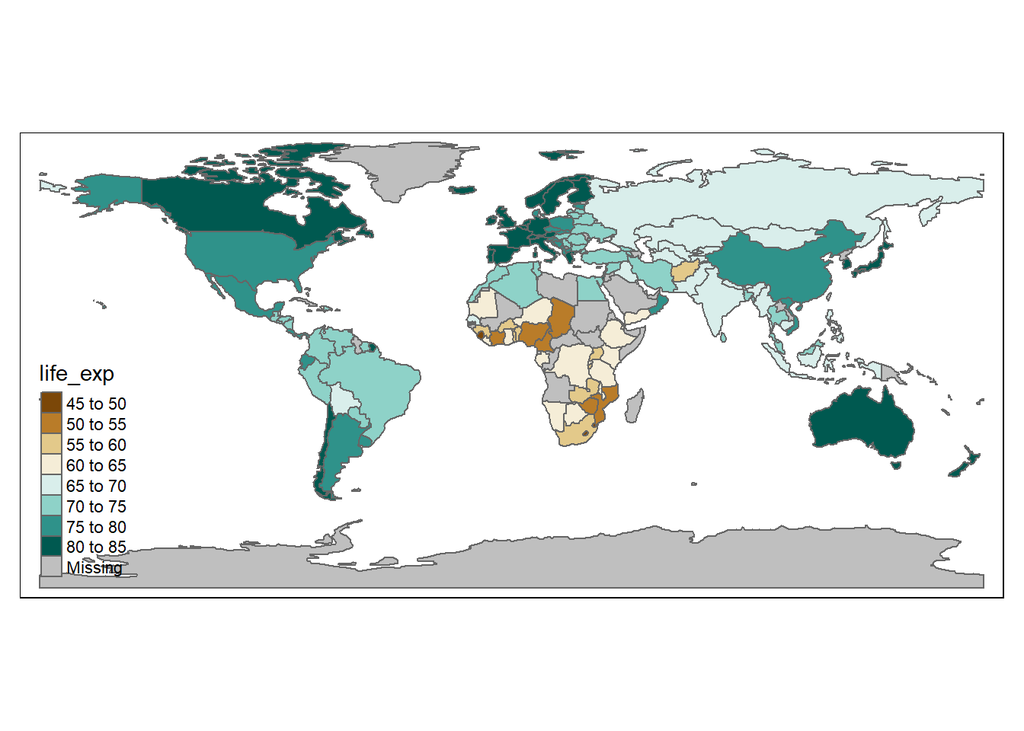

```r
#using median life expectancy from dataset as midpoint of color palette
median_life <- median(World$life_exp)
tm_shape(World)+
  tm_polygons(col = "life_exp", palette = "BrBG", midpoint = median_life)
```

### Using colors for categorical variables

Since this dataset has 8 continents, so 8 colors.

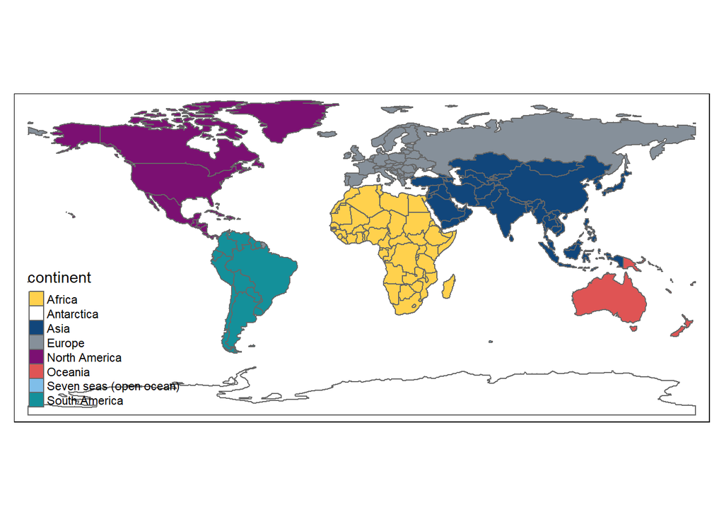

```r
#categorical palette
tm_shape(World)+
  tm_polygons(col = "continent",
              palette = c(
                "Asia" = "#11467b",
                "Africa" = "#ffd14d",
                "Europe" = "#86909a",
                "South America" = "#14909a",
                "Antarctica" = "white",
                "Seven seas (open ocean)" = "#7fbee9",
                "Oceania" = "#df5454",
                "North America" = "#7b1072"
              ))
```

### Difference between Categorical maps and Discrete maps

In the World dataset, continent column is categorical. It contains characters and is a factor with 8 levels. It is a qualitative variable. If map is created using `col="continent"`, then each level gets one distinct color. Such map is categorical map.

In the same dataset, population column is numeric and has wide range of values. When such variable is provided to tmap `col="pop_est`, it creates some number of class intervals. Each interval gets a color. Now, the intervals can be colored using sequential colors or categorical. This map is discrete map.(it’s not categorical. The variable provided to `col` argument is numeric and quantitative.)

### Discrete maps

`style` argument of `tm_polygons()` is used to create discrete maps. When such variable is given to `col` parameter, tmap understands the variable type and uses `pretty` style by default. When `style="pretty"`, the breaks created are whole numbers and are evenly spaced.

There are 14 options available for style argument. Along with it, desired number of classes can also be specified using the `n` argument.

### Creating breaks in maps.

#### 1. Manually specifying breaks

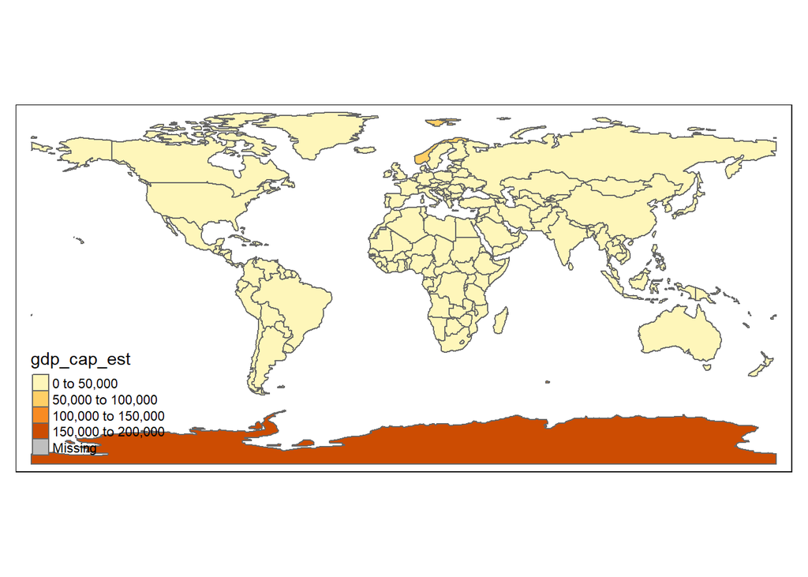

```r
#trying out breaks.
tm_shape(World)+
  tm_polygons(col = "gdp_cap_est")
```

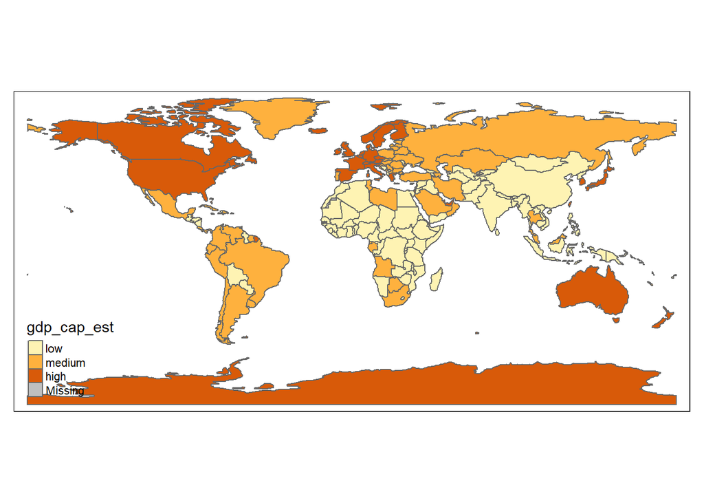

```r
#adding breaks
tm_shape(World)+
  tm_polygons(col = "gdp_cap_est",
              breaks = c(0, 7000, 25000, 200000),
              labels = c("low", "medium", "high"))
```

#### 2. Automatically specifying breaks.

By specifying one of “equal”, “sd”, and “quantile” styles in `style` argument.  
1. **“equal”** can be used when the variable doesn’t have any outliers; here, the entire range of values are divided into n number of classes/intervals.  
2. **“quantile”** creates classes with same number of elements in all intervals but the intervals can be of varying widths.  
3. **“sd”** is used to display how much values differ from mean. In this case, width of each interval remains same, i.e. 1 standard deviation. For e.g. creating a map to show which all countries fall withing 1 standard deviation from mean, which fall within 2 standard deviations etc.

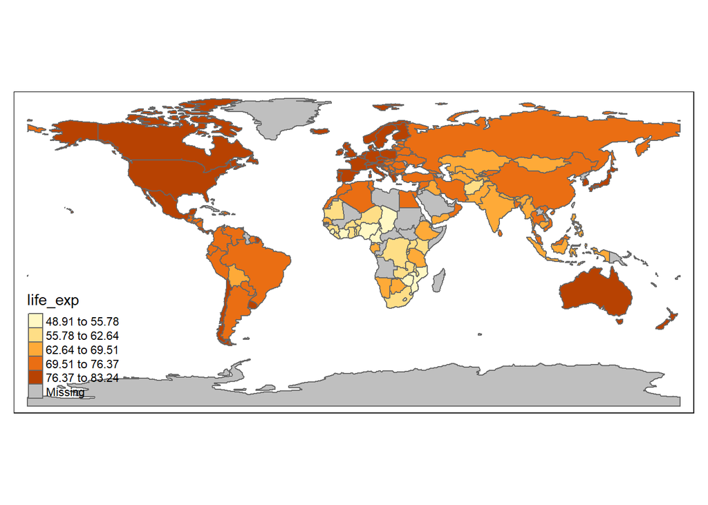

```r
#class intervals of "life_exp" created with equal width
tm_shape(World)+
  tm_polygons(col = "life_exp", style = "equal")
```

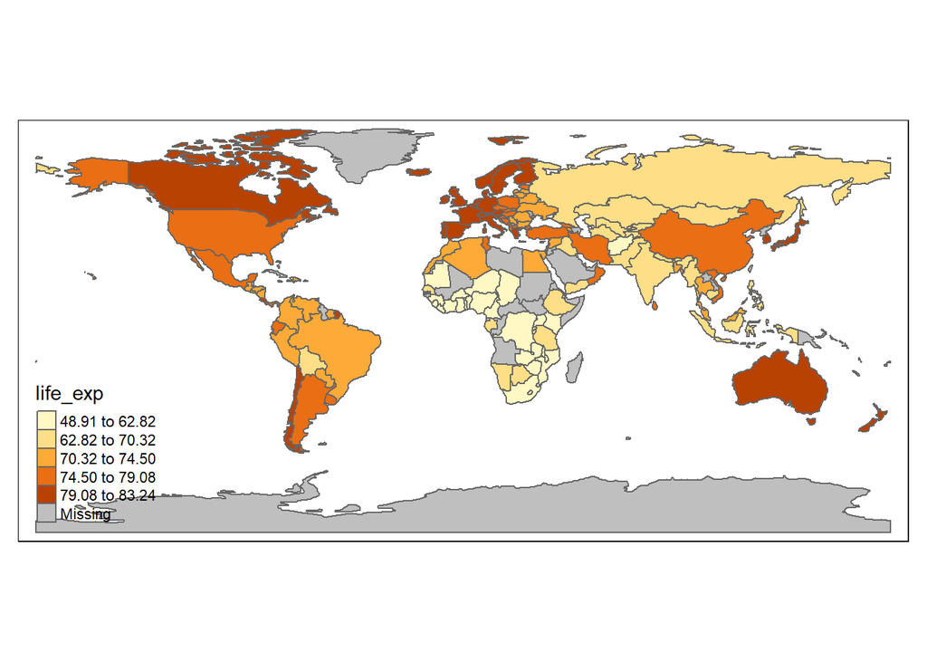

```r
#class intervals with same number of values in each class. 25%
tm_shape(World)+
  tm_polygons(col = "life_exp", style = "quantile")
```

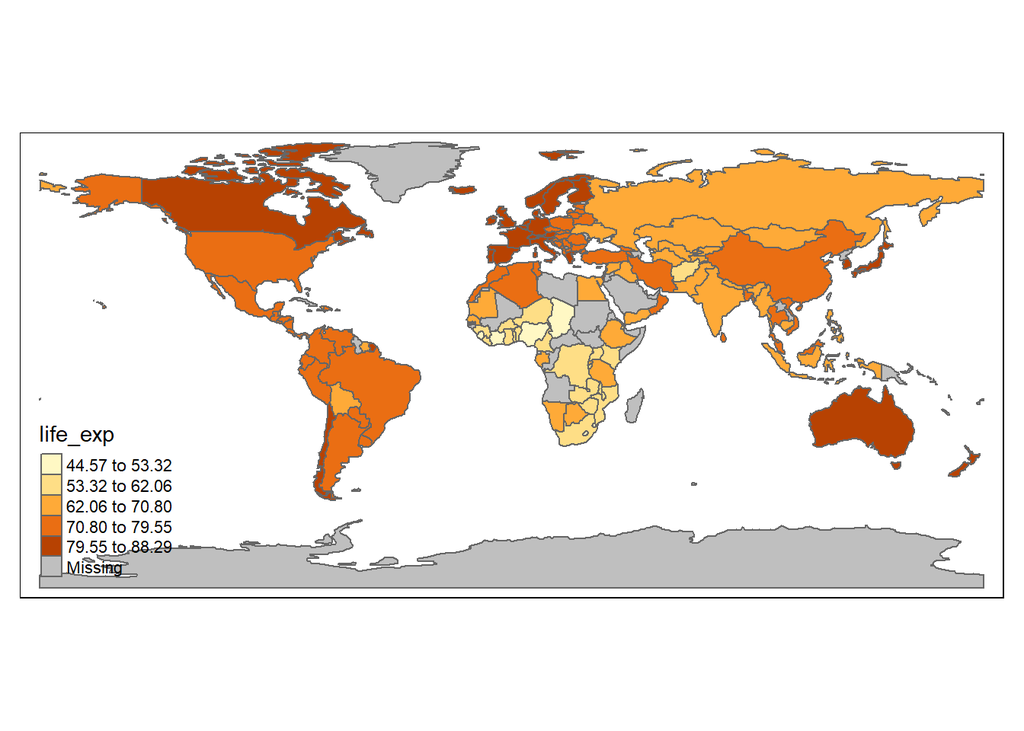

```r
#class interval has size = stardard deviation of life expectancy
tm_shape(World)+
  tm_polygons(col = "life_exp", style = "sd")
```

```r
# (life_sd <- sd(World$life_exp, na.rm = T))
# (life_mean <- mean(World$life_exp, na.rm = T))
```

#### 3. Using classification techniques to specify breaks

1. “Jenks” is an optimization method used in creating classes. It is set by using `style="jenks"`.
2. `style="dpih"` uses kernel density estimation technique to select width of intervals.
3. Creating class intervals using clustering techniques- `style="kmeans"` OR `style=bclust` (Bagged clustering) OR `style=hclust` (Hierarchical clustering).
4. `style=headtails` used for right skewed data.
5. `style=log10pretty` - log 10 transformation applied to class intervals.

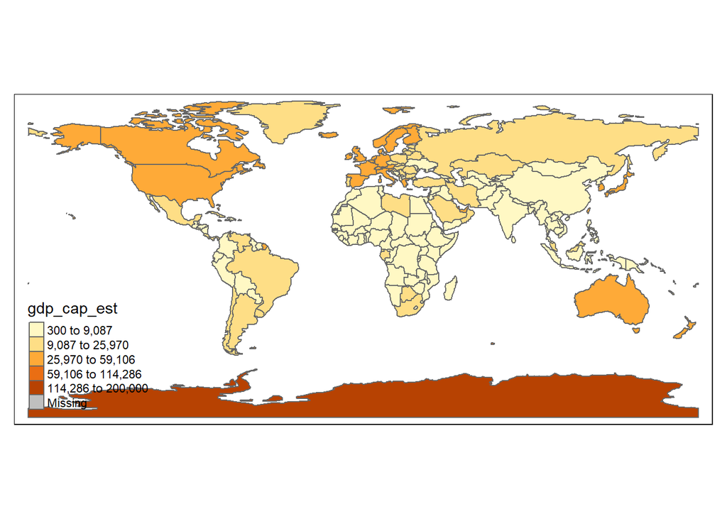

```r
tm_shape(World)+
  tm_polygons(col = "gdp_cap_est",
              style = "jenks")
```

### Maps using continuous variable.

3 continuous methods present in tmap. They can be applied to style argument- `cont`, `order` and `log10`.

`order` and `log10` are used when data is skewed.

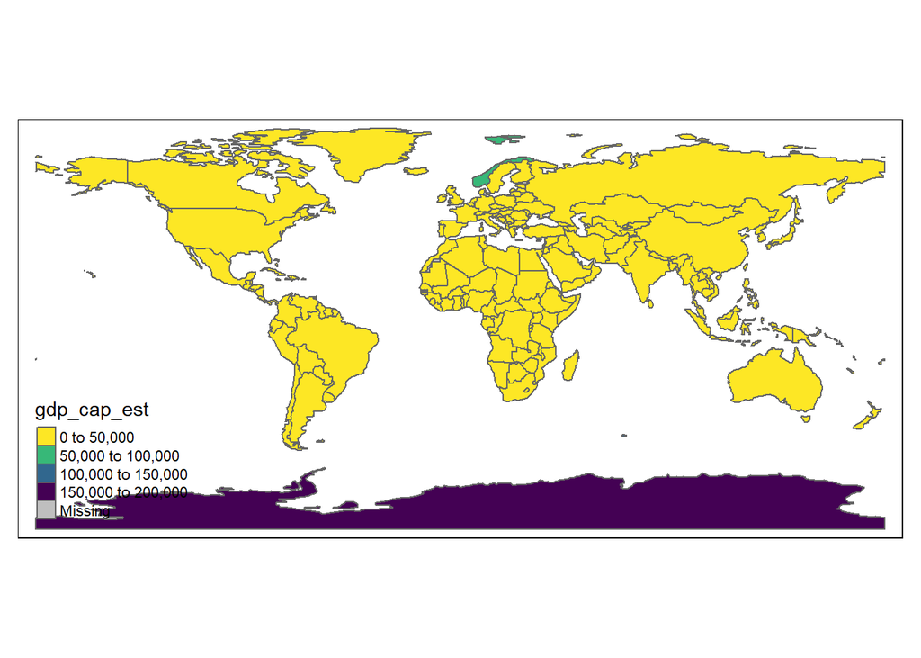

```r
tm_shape(World)+
  tm_polygons(col = "gdp_cap_est", style = "pretty", palette = "-viridis")
```

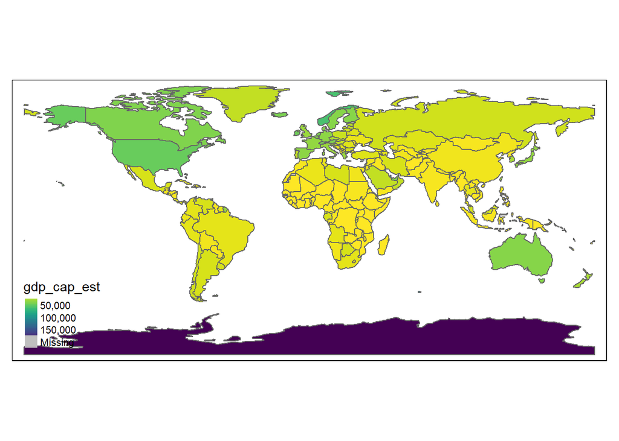

```r
tm_shape(World)+
  tm_polygons(col = "gdp_cap_est", style = "cont", palette = "-viridis")
```

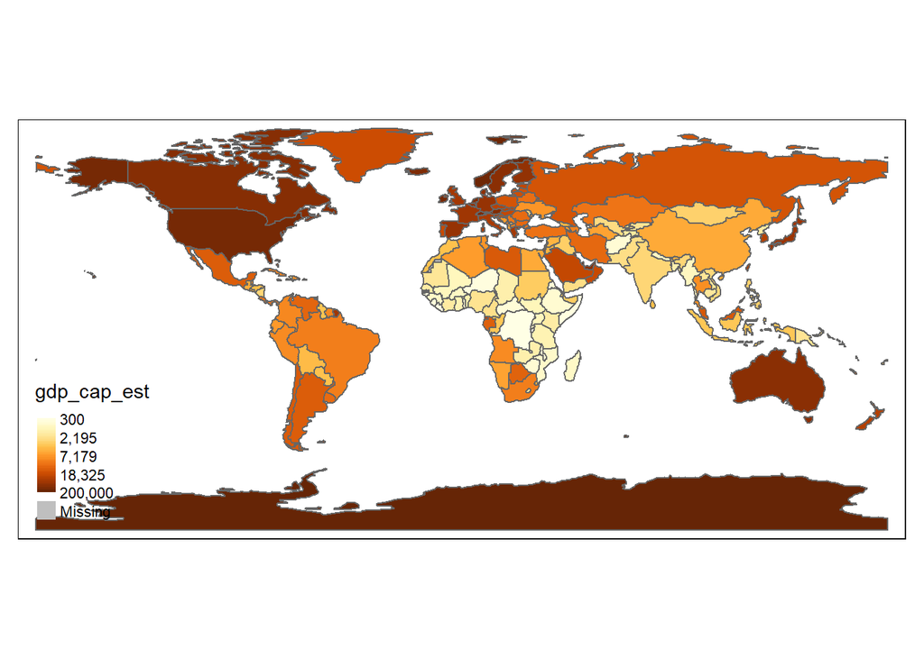

```r
tm_shape(World)+
  tm_polygons(col = "gdp_cap_est", style = "order")
```

Another way of coloring the polygons is by specifying `col="MAP_COLORS"`. In this case, the polygons get colored in such a way that adjacent polygons do not get same colors.

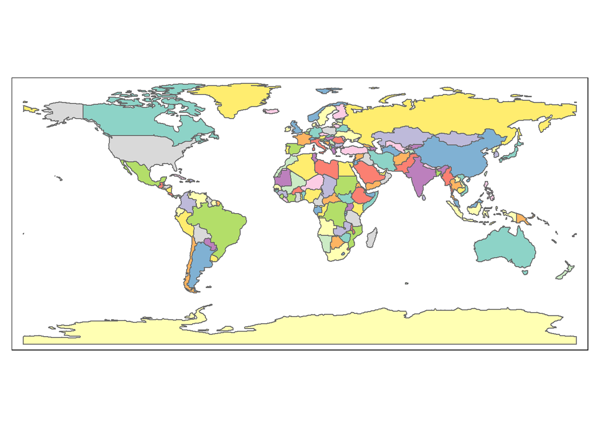

```r
tm_shape(World)+
  tm_polygons(col = "MAP_COLORS")
```

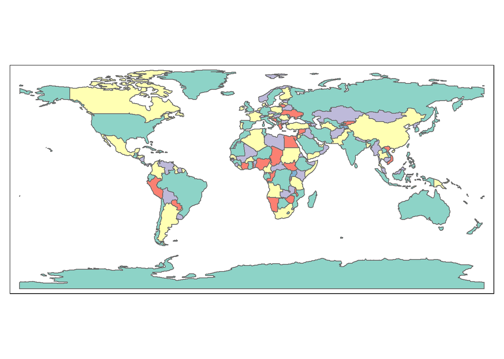

```r
#to use minimum number of colors to display all countries.
tm_shape(World)+
  tm_polygons(col = "MAP_COLORS", minimize = T) #see in map, only 4 colors color entire map as compared to previous one.
```

### Creating shapes

Here, I have downloaded a metro symbol to display all metro cities with it. By default, it is displayed using dots. First, this png file is read and converted to tmap object using `tmap_icon()` function. Then, this object is applied to `shape` argument of tm_symbols().

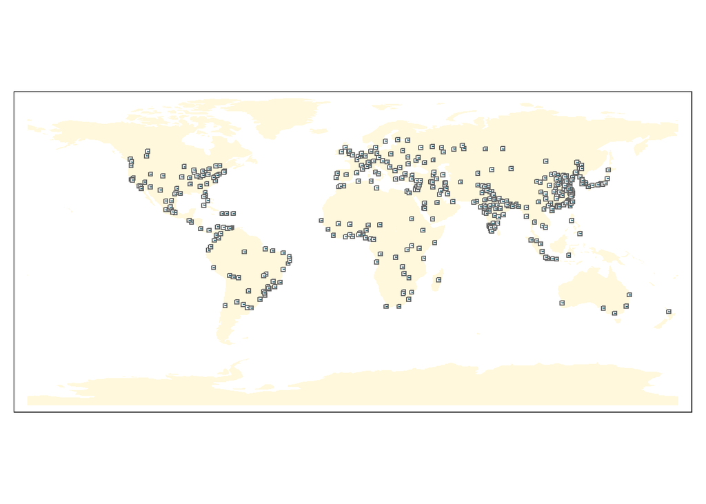

```r
#reading metro symbol png
metro_icon <- tmap_icons(paste0(getwd(), "/images/metro_symbol.png"))

tm_shape(World)+
  tm_fill(col = "cornsilk")+
tm_shape(metro)+
  tm_symbols(shape = metro_icon, size = 0.01)
```